# Modelos matemáticos para ciencia de datos

## Introducción a las regresiones lineales

### Centro Turing

En esta unidad vamos a introducir las regresiones lineales y familias de modelos relacionadas.

El propósito es dar el primer paso en los modelos más actuales que están emergiendo en la industria, como el aprendizaje automático y la inteligencia artificial.

Sin embargo, los modelos que analizaremos tienen raíces profundas en áreas clásicas como la estadística y la economética.

Explicaremos porque los modelos lineales son utiles para evaluar procesos en ciencia de datos y que módulos de Python necesitaremos para implementarlos de manera eficiente.

#### Relación con la ciencia de datos

Algunas aplicaciones de la ciencia de datos son:

1. En publicidad, entregar anuncios personalizados.
2. En comercio electrónico, hacer ofertas más relevantes para a los usuarios.
3. En el negocio del crédito o de los seguros, una aplicación que selecciona si procede a las consultas en línea de los usuarios, basándose en su calificación crediticia y en su relación anterior con la empresa.

Si bien existen modelo más sofisticados para realizar la modelación de estos problemas, la regresión lineal nos ofrece una herramienta sencilla, fácil de entrenar y con buenos resultados.

#### Oportunidades en la ciencia de datos

Una de la restricciones más importantes que teníamos en el pasado era la disponibilidad de los datos. Sin embargo, ahora tenemos cantidad abundantes y barata de información y la oportunidad de aprender de esta.

Al estar en la intersección de la experiencia (saber cómo hacer negocios y obtener beneficios), el aprendizaje automático y las habilidades de hacking (integrar varios sistemas y fuentes de datos), la ciencia de los datos promete encontrar la mezcla de herramientas para aprovechar datos disponibles y convertirlos en beneficios.

# Retos

Sin embargo, existen algunos inconvenientes al implementrar estas solciones.

1. El procesamiento de datos sin estructura
2. Extraer datos de fuentes heterogéneas
3. Aprender de los datos reglas generales que permitan hacer predicciones correctas
4. Entender realmente el modelo y poder comunicar los resultados
5. Escalar los modelos para que hagan predicciones en tiempo real

#### Modelos lineales

Al iniciar en aprendizaje automático, aprenderemos dos modelos básicos, a saber, regresiones lineales y logísticas.

Existe abundante literatura sobre el tema, pero debemos estar siempre conscientes de su alcance y limitaciones: Quizá no sea la mejor herramienta, pero sí es un excelente punto de partida para analizar nuestros datos.

Inclusive, a veces se pueden entregar mejores resultados con modelos lineales que con otros más complicados, siempre y cuando estén alimentados con datos de buena calidad. Véase por ejemplo el artículo [The Unreasonable Effectiveness of Data.](https://research.google.com/pubs/archive/35179.pdf)

En este sentido, una ventaja de los modelos lineales es que pueden adaptarse mucho más rápido y son más fáciles de desarrollar.

### Python aplicado a la ciencia de datos

Hemos elegido Python por varías razones. Algunas de estas son:

1. Es un lenguaje de propósito general y de código abierto
2. Tiene una sintaxis sencilla y fácil de aprender
3. Sobre todo, se ha convertido en uno de los lenguajes preferidos por los científicos de datos en todo el mundo

A continuación darremos un ejemplo sencillo de su uso en la visualización de datos. Para esto usaremos el conjunto de datos [Boston house prices dataset](https://scikit-learn.org/stable/datasets/toy_dataset.html). Antes de continuar, lee la documentación anterior para comprender el desarrollo del problema.

```python
# Pandas es un módulo especializado en el procesamiento de datos
import pandas as pd
#  Scikit-learn lo es en aprendizaje automático
# Importatemos un conjunto de datos incluído en este módulo
from sklearn.datasets import load_boston
# Ahora procesaremos los datos para poder visualizarlos
# Cargamos el conjunto de datos en la memoria
boston = load_boston()
# Convertimos el conjunto de datos en un marco de datos
dataset = pd.DataFrame(boston.data,
                      columns=boston.feature_names)
# Imprimimos en pantalla los cinco primeros registros.
dataset.head()
```

|  | CRIM | ZN | INDUS | CHAS | NOX | RM | AGE | DIS | RAD | TAX | PTRATIO | B | LSTAT |
| --- | --- | --- | --- | --- | --- | --- | --- | --- | --- | --- | --- | --- | --- |
| 0 | 0.00632 | 18.0 | 2.31 | 0.0 | 0.538 | 6.575 | 65.2 | 4.0900 | 1.0 | 296.0 | 15.3 | 396.90 | 4.98 |
| 1 | 0.02731 | 0.0 | 7.07 | 0.0 | 0.469 | 6.421 | 78.9 | 4.9671 | 2.0 | 242.0 | 17.8 | 396.90 | 9.14 |
| 2 | 0.02729 | 0.0 | 7.07 | 0.0 | 0.469 | 7.185 | 61.1 | 4.9671 | 2.0 | 242.0 | 17.8 | 392.83 | 4.03 |
| 3 | 0.03237 | 0.0 | 2.18 | 0.0 | 0.458 | 6.998 | 45.8 | 6.0622 | 3.0 | 222.0 | 18.7 | 394.63 | 2.94 |
| 4 | 0.06905 | 0.0 | 2.18 | 0.0 | 0.458 | 7.147 | 54.2 | 6.0622 | 3.0 | 222.0 | 18.7 | 396.90 | 5.33 |

```python
# Imprimimos la información básica
dataset.info()
```

```
<class 'pandas.core.frame.DataFrame'>
RangeIndex: 506 entries, 0 to 505
Data columns (total 13 columns):
 #   Column   Non-Null Count  Dtype
---  ------   --------------  -----
 0   CRIM     506 non-null    float64
 1   ZN       506 non-null    float64
 2   INDUS    506 non-null    float64
 3   CHAS     506 non-null    float64
 4   NOX      506 non-null    float64
 5   RM       506 non-null    float64
 6   AGE      506 non-null    float64
 7   DIS      506 non-null    float64
 8   RAD      506 non-null    float64
 9   TAX      506 non-null    float64
 10  PTRATIO  506 non-null    float64
 11  B        506 non-null    float64
 12  LSTAT    506 non-null    float64
dtypes: float64(13)
memory usage: 51.5 KB
```

```python
"""
Para las variables numéricas, podemos hacer un
análisis básico de los estadísticos
"""
dataset.describe()
```

|  | CRIM | ZN | INDUS | CHAS | NOX | RM | AGE | DIS | RAD | TAX | PTRATIO | B | LSTAT |
| --- | --- | --- | --- | --- | --- | --- | --- | --- | --- | --- | --- | --- | --- |
| count | 506.000000 | 506.000000 | 506.000000 | 506.000000 | 506.000000 | 506.000000 | 506.000000 | 506.000000 | 506.000000 | 506.000000 | 506.000000 | 506.000000 | 506.000000 |
| mean | 3.613524 | 11.363636 | 11.136779 | 0.069170 | 0.554695 | 6.284634 | 68.574901 | 3.795043 | 9.549407 | 408.237154 | 18.455534 | 356.674032 | 12.653063 |
| std | 8.601545 | 23.322453 | 6.860353 | 0.253994 | 0.115878 | 0.702617 | 28.148861 | 2.105710 | 8.707259 | 168.537116 | 2.164946 | 91.294864 | 7.141062 |
| min | 0.006320 | 0.000000 | 0.460000 | 0.000000 | 0.385000 | 3.561000 | 2.900000 | 1.129600 | 1.000000 | 187.000000 | 12.600000 | 0.320000 | 1.730000 |
| 25% | 0.082045 | 0.000000 | 5.190000 | 0.000000 | 0.449000 | 5.885500 | 45.025000 | 2.100175 | 4.000000 | 279.000000 | 17.400000 | 375.377500 | 6.950000 |
| 50% | 0.256510 | 0.000000 | 9.690000 | 0.000000 | 0.538000 | 6.208500 | 77.500000 | 3.207450 | 5.000000 | 330.000000 | 19.050000 | 391.440000 | 11.360000 |
| 75% | 3.677083 | 12.500000 | 18.100000 | 0.000000 | 0.624000 | 6.623500 | 94.075000 | 5.188425 | 24.000000 | 666.000000 | 20.200000 | 396.225000 | 16.955000 |
| max | 88.976200 | 100.000000 | 27.740000 | 1.000000 | 0.871000 | 8.780000 | 100.000000 | 12.126500 | 24.000000 | 711.000000 | 22.000000 | 396.900000 | 37.970000 |

```python
"""
 Ahora vamos a crear una nueva varible, que es el precio de la casa.
 En este caso el objetivo es el valor de  las viviendas ocupadas por
 sus propietarios en  miles de dólares.
"""
dataset["target"] = boston.target
dataset["target"].describe()
```

```
count    506.000000
mean      22.532806
std        9.197104
min        5.000000
25%       17.025000
50%       21.200000
75%       25.000000
max       50.000000
Name: target, dtype: float64
```

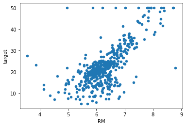

```python
"""
Finalmente visualizaremos un diagrama de dispersión comparando la variable
objetico con el predictor RM, que es el número medio de habitaciones por vivienda.
"""
diagrama = dataset.plot(kind="scatter", x="RM", y="target")
```

### Módulos que utilizaremos

Ahora vamos a presentar algunos módulos que utilizaremos en nuestro curso.

#### Numpy

NumPy, que es una creación de Travis Oliphant, está en el centro de toda solución analítica en el lenguaje Python. Proporciona al usuario matrices multidimensionales, junto con un gran conjunto de funciones para operar múltiples operaciones matemáticas en estas matrices.

```python
"""
Para importar numpy o cualquier paquete utilizamos la clave `import`.
Sin embargo, Python nos permite poner un alias con la clave `as`.
La convención para importar Numpy es la siguiente:
"""
# Para instalar en línea, utilizamos el comando
# !pip install numpy
import numpy as np

# también podemos importar submódulos especificos
# Para esto ocuparemos la forma from ... import
from numpy import linalg
```

```python
# Desarrollemos un ejemplo sencillo de álgebra lineal
# Primero generamos una matriz aleatoria
M = np.random.randint(0, 11, size=(3,3))
print("Matriz:\n",M)
print("\nDeterminante:\n",linalg.det(M))
```

```
Matriz:
 [[3 1 2]
 [2 0 5]
 [5 9 5]]

Determinante:
 -83.99999999999999
```

```python
# Ahora intentaremos calcular su inversa
try:
    M_inversa = linalg.inv(M)
    print("\nInversa:\n",  M_inversa)
    print("\nIdentidad\n:", np.matmul(M, M_inversa))
except Exception as e:
    print(e)
```

```
Inversa:
 [[ 0.53571429 -0.1547619  -0.05952381]
 [-0.17857143 -0.05952381  0.13095238]
 [-0.21428571  0.26190476  0.02380952]]

Identidad
: [[ 1.00000000e+00  1.11022302e-16 -2.08166817e-17]
 [-1.94289029e-16  1.00000000e+00 -1.04083409e-17]
 [-1.94289029e-16  2.77555756e-16  1.00000000e+00]]
```

#### Scipy

Un proyecto original de Travis Oliphant, Pearu Peterson y Eric Jones, SciPy completa las funcionalidades de NumPy, ofreciendo una mayor variedad de algoritmos científicos para para álgebra lineal, matrices dispersas, procesamiento de señales e imágenes, optimización, transformación rápida de Fourier y mucho más. rápida de Fourier, y mucho más.

El paquete scipy.optimize proporciona varios algoritmos de optimización de uso común, utilizados para detallar cómo se puede estimar un modelo lineal utilizando diferentes enfoques de optimización de optimización.

```python
"""
Para instalar scipy utiliza la línea
!pip install scipy
La convención para importar es
"""
import scipy as sp
```

#### Scikit-learn

Iniciado como parte de los SciPy Toolkits (SciKits), Scikit-learn es el núcleo de las operaciones de ciencia de datos en Python. Ofrece todo lo que puede necesitar en términos de preprocesamiento de datos, aprendizaje supervisado y no supervisado, selección de modelos, validación y métricas de error.

Scikit-learn comenzó en 2007 como un proyecto de Google Summer of Code por David Cournapeau. Desde 2013, ha sido asumido por los investigadores del INRA (Instituto Francés de Investigación en Informática y Automática).

Scikit-learn ofrece módulos para:

1. El procesamiento de datos (sklearn.preprocessing, sklearn.feature_extraction),
2. la selección de modelos y la validación (sklearn.cross_validation, sklearn.grid_search y sklearn.metrics) y
3. un conjunto completo de métodos (sklearn.linear_model) en los que se espera que el valor objetivo, ya sea un número o una probabilidad, sea una combinación lineal de las variables de entrada

#### Statsmodels

Anteriormente parte de Scikit, Statsmodels ha sido pensado como un complemento de las funciones estadísticas de SciPy. Ofrece modelos lineales generalizados, modelos de elección discreta, análisis de series temporales y una serie de estadísticas descriptivas, así como pruebas paramétricas y no paramétricas.

En Statsmodels, utilizaremos los módulos statsmodels.api y statsmodels.formula.api, que proporcionan funciones para ajustar modelos lineales proporcionando tanto matrices de entrada como especificaciones de fórmulas:

```python
"""
Convención para importar Statsmodels
"""
import statsmodels.api as sm
import statsmodels.formula.api as smf
```

En la próxima unidad presentaremos la regresión lineal desde sus fundamentos estadísticos. Partiendo de la idea de correlación, construiremos la regresión lineal simple (utilizando un solo predictor) y proporcionaremos las formulaciones del algoritmo